# Francesco/Esteves/Valle Model — Full Analysis with Sector Benchmarks

Evaluates the **Francesco/Esteves/Valle Model** portfolio, optimised against benchmarks built from the **11 GICS sectors (Global Industry Classification Standard)** (equal-weighted return of each S&P 500 sector).

| Model | Optimisation benchmark |
| --- | --- |
| **Francesco/Esteves/Valle Model** | Synthetic benchmark $=\max_k\bigl(\mathrm{Tail}_{s/S^k}\bigr)$ over the 11 sectors |
| **Roman Model (Scaled)** | SP500 (reference) |
| **Francesco/Esteves/Valle Model (Factors)** | Synthetic benchmark over the Fama-French factors |

> **v2** — revision of this analysis following the alignment meeting of 2026-07-23. The points raised at that meeting and the corrections applied relative to v1 are listed in the section below.

## Open items — meeting of 2026-07-23

Items raised at the meeting that are **not** covered by this notebook, with what each one requires.

| # | Open item | What it takes | Status |
| --- | --- | --- | --- |
| 6 | **2×2 grid of models** — Rome *scaled*, Rome *unscaled*, this work *scaled*, this work *unscaled* | Implemented: the **Francesco/Esteves/Valle Model (Unscaled)** — the same sector formulation used in this work, replacing the max-min constraint $\frac{s}{S}V \le V_s$ with $V \le V_s$ — and the **Roma… | **done** |
| 7 | **Scalarisation applied to the unscaled model** | This is item 6 itself: applying the factor $k/S$ to the unscaled model is equivalent to moving from the Tail formulation to the CVaR one. Covered by section *14d* | **done** |
| 8 | **Equivalence test** — original formulation (all constraints, all benchmarks) vs. synthetic-benchmark formulation | Run the **Rome formulation (MultiSSD)** with the 11 sectors and compare it against the **Francesco/Esteves/Valle Model**. The two must converge to the **same optimal solution**, with different solutio… | **done** |
| 9 | **Longer OOS period** | Out of scope for this revision, by decision | deferred |
| 10 | **Minimum variance as a historical benchmark** | Implement the minimum-variance portfolio and include it in the comparison | pending |
| 17 | **Submission** — discuss with Cristiano, incorporate Francesco's model | Not code | pending |

**Hypothesis recorded for item 6.** The expectation raised at the meeting is that this work's formulation outperforms Rome's under both regimes — *scaled* (CVaR) and *unscaled* (Tail) — thanks to the gain from tail maximisation. The test in item 8 is logically prior: comparing performance only makes sense after confirming that the synthetic-benchmark reformulation preserves the optimal solution.

Note that the two dimensions of the 2×2 grid are independent and test different things: the Rome/synthetic axis tests **equivalence** (the solutions must coincide, only the solution time changes), whereas the scaled/unscaled axis tests **preference** (the solutions must diverge, because the objective functions are genuinely different).

**Loading hooks.** Once the models in open items 6, 8 and 10 are run, they need only write their portfolios under the standard output path; this notebook's loading block checks for the file and then includes them automatically in every figure and table.

### Summary of the corrections applied in this v2

| Meeting item | Where |
| --- | --- |
| 1 — synthetic benchmark computation (`cumsum` → `max`) | already fixed in the **Francesco/Esteves/Valle Model**; this notebook consumes the resulting $\tau$ |
| 2 — synthetic benchmark labels per window | section *Synthetic Benchmark per rebalancing window* |
| 3 — check whether the synthetic benchmark coincides with Energy | section *Synthetic benchmark vs. ENERGY* |
| 4 — redo the drawdown panel | section *Comparative drawdown* (shared scale, maximum markers) |
| 5 — inverted colours in Max Drawdown | metrics table |
| 11 — drawdown and CAGR formulas | sections *Drawdown definition* and *Metrics — definitions* |
| 12 — semi-volatility | column `Semi-volatility (%)` and corrected Sortino |
| 13 — mean return (numerator of Sharpe/Sortino) | column `Mean return (%)` |
| 14 — beta explicitly against the SP500 | column `Beta vs SP500` and summary header |
| 15 — stochastic dominance as a number | columns `min SSD`, `% ranks SSD≥0`, `Violation area` |
| 16 — additional metrics | `Calmar Ratio`, in addition to those above |
| model taxonomy | section *0. Model taxonomy* — scaled ⟺ CVaR, unscaled ⟺ Tail, with the derivation |

## Experiment configuration

| Parameter | Value |
| --- | --- |
| **Model** | TAF-MultiSSD — multi-benchmark SSD with a synthetic benchmark (*max_k* operator) |
| **Formulation** | MIP with lazy constraints (CPLEX callback; dummy binary variable) |
| **In-sample window** | 200 days (sliding window) |
| **Universe** | ~505 S&P 500 constituents (after dropping assets with >15% missing values) |
| **Benchmark** | Synthetic $=\max_k\bigl(\mathrm{Tail}_{s/S^k}\bigr)$ over the 11 GICS sectors |
| **Rebalancing frequency** | Every 21 trading days |
| **Out-of-sample period** | 2024-01-02 to 2024-06-01 |
| **Number of rebalancings** | 5 |
| **Transaction costs** | None |
| **Minimum lots** | None |

**Structure:**

- Points from the 2026-07-23 meeting and corrections applied in this v2
0. Model taxonomy
1. Setup
2. Loading data and models
3. Market context — OOS sectors
4. OOS synthetic benchmark — dominant sector
5. Constraint tightness — $\tau_k$ per sector per window
6. Dominant sector per rank (+ numerical summary) 6b. Synthetic benchmark vs. ENERGY — coincidence check
7. Overview — portfolio vs sectors
8. Comparative drawdown (+ formal definition)
9. OOS metrics — full table (+ definitions)
10. SSD dominance 10b. SSD dominance — CDFs and cumulative integrals (scaled × unscaled grid) 10c. r_P vs r_B by quantile — tail analysis
11. Risk × return analysis
12. Distribution and correlation
13. Rolling-window returns
14. Executive summary 14b. Solver diagnostics (CPLEX) 14c. Equivalence test — original formulation (K sectors) vs. synthetic benchmark 14d. 2×2 grid — Roman vs. this work × scaled vs. unscaled

## 0. Model taxonomy

An alignment point from the meeting: the names had been used ambiguously. Two dimensions, and only two, distinguish the models in this project.

**Dimension 1 — scaling, which is the same as the choice of tail measure.** With $S$ equiprobable scenarios and order statistics $r_{(1)} \le \dots \le r_{(S)}$, the two tail measures at rank $k$ (level $p = k/S$) are:

$$\mathrm{Tail}_{p}(R) \;=\; \frac{1}{S}\sum_{s=1}^{k} r_{(s)} \qquad\qquad \mathrm{CVaR}_{p}(R) \;=\; \frac{1}{k}\sum_{s=1}^{k} r_{(s)}$$

**Tail** is the *unconditional* expectation of the $k$ worst scenarios; **CVaR** is the *conditional* one. Each is a rescaling of the other:

$$\mathrm{Tail}_{p}(R) \;=\; p \cdot \mathrm{CVaR}_{p}(R), \qquad p = k/S$$

It is precisely this factor $p$ that appears in the max-min constraint and gives the model its name:

|  | Max-min constraint | Resulting objective |
| --- | --- | --- |
| **Unscaled** | $V \le V_k$ | $V^\star = \min_k \sum_{s\le k}\left(r_{P,(s)} - r_{B,(s)}\right) = S\cdot\min_k\left[\mathrm{Tail}_{k/S}(R_P) - \mathrm{Tail}_{k/S}(R_B)\right]$ |
| **Scaled** | $\frac{k}{S}\,V \le V_k$ | $V^\star = \min_k \dfrac{\mathrm{Tail}_{k/S}(R_P) - \mathrm{Tail}_{k/S}(R_B)}{k/S} = \min_k\left[\mathrm{CVaR}_{k/S}(R_P) - \mathrm{CVaR}_{k/S}(R_B)\right]$ |

In other words: **the *scaled* model maximises the smallest CVaR difference; the *unscaled* one, the smallest Tail difference.**

> **Beware of a naming ambiguity.** The unconditional expectation $\mathrm{Tail}$ is the measure that appears in the constraints of **both** variants: it is always the one describing the tail profile of the benchmark ($\tau_k[s] = \mathrm{Tail}_{s/S^k}$) and of the portfolio. What distinguishes *scaled* from *unscaled* is **not** the measure used in the constraint, but the coefficient multiplying $V$ in the max-min constraint:

> $$\underbrace{\frac{s}{S}\,V \;\le\; V_s}_{\text{scaled}} \qquad\text{vs.}\qquad \underbrace{V \;\le\; V_s}_{\text{unscaled}}, \qquad\text{with}\qquad V_s \;\le\; \mathrm{Tail}_{s/S}(R_P) - \tau_k[s] \ \text{ in both.}$$

> Dividing by $s/S$ converts the Tail difference into a CVaR difference — hence the equivalence *scaled* ⟺ CVaR. Therefore, reading "$\tau_k$ is the unconditional expectation" in the sections that follow does **not** mean that the model described there is the *unscaled* one: it is the *scaled* model, and its $\tau$ is the same as the *unscaled* model's.

**Dimension 2 — how the $K$ benchmarks enter the problem.**

- **Rome formulation (Cristiano)** — imposes the SSD constraints for *all* scenarios **and** *all* $K$ benchmarks, with $K$ sets of variables $V_{k,t}$.
- **Synthetic-benchmark formulation (this work)** — replaces the $K$ benchmarks with a single one, $\tau_{\text{synth}}[s] = \max_k \mathrm{Tail}_{s/S^k}(I^k)$, with a single set of $V_t$.

The two **must produce the same optimal solution**; the second is an equivalent reformulation that is cheaper to solve. Verifying this empirically is addressed in section *14c*.

### Why the choice changes the optimal portfolio

As a *feasibility test* the two are equivalent — $V^\star \ge 0$ holds in one if and only if it holds in the other, and both characterise SSD dominance. The difference lies in the *objective function*, when dominance is not attainable and the model must choose the "least bad" solution.

In the **unscaled** model every rank enters with weight $1/S$. Since the Tail difference at small $k$ is a sum of few terms, it is mechanically small — the minimum tends to be attained in the middle or upper part of the distribution, and the extreme tail barely competes for the binding position.

There is also a difference in how $V^\star$ is interpreted. In the scaled model it is scale-free and reads directly: *the portfolio's CVaR exceeds the benchmark's by at least $V^\star$ at every confidence level*. In the unscaled model, $V^\star$ is in units of cumulative return and grows with $S$, which makes it incomparable across windows of different sizes.

## 1. Setup

```
ROOT: /media/toni/Dados/Git/ssd-multi
Available sectors (11): ['BASIC_MATERIALS', 'CONSUMER_CYCLICALS', 'CONSUMER_NON_CYCLICALS', 'ENERGY', 'FINANCIALS', 'HEALTHCARE', 'INDUSTRIALS', 'REAL_ESTATE', 'TECHNOLOGY', 'TELECOMMUNICATIONS_SERVICES', 'UTILITIES']
```

## 2. Loading data and models

```
Market data  : (305, 509)
OOS          : 2024-01-02 → 2024-05-31  (105 days)
Sectors      : (304, 11)
```

```
Models loaded (5):
  Francesco/Esteves/Valle Model             final = 1.6089  (+60.89%)
  Roman Model (Scaled)                      final = 1.4911  (+49.11%)
  Francesco/Esteves/Valle Model (Unscaled)  final = 1.1327  (+13.27%)
  Roman Model (Unscaled)                    final = 1.0907  (+9.07%)
  Francesco/Esteves/Valle Model (Factors)   final = 1.2230  (+22.30%)
```

## 3. Market context — OOS sectors

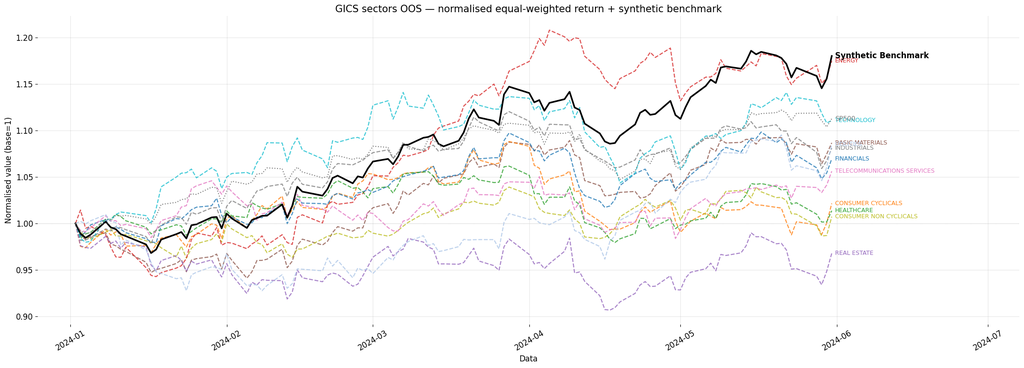

**Market context (overview of the OOS sectors)**

The chart shows the normalised performance of the 11 GICS sectors over the out-of-sample period. The solid black line (Synthetic Benchmark) is the compounded synthetic distribution, built with the same formulation used in the optimisation,

$$\max_k\Bigl(\mathrm{Tail}_{s/S^k}\bigl(R(I^k)\bigr)\Bigr)$$

applied to the OOS sector returns, with the implied returns assigned to dates by *quantile matching* (the worst synthetic return falls on the worst day of the cross-sector mean return). The spread across sectors reveals the heterogeneity of the OOS environment: a well-optimised portfolio should outperform most sectors individually; the Synthetic Benchmark ends the period close to the best sector — at each tail level it adopts the requirement of the most demanding sector, but, being a distribution (and not an envelope of trajectories), it can be crossed at individual points by single sectors. Sectors below 1.0 posted absolute losses over the period and imposed looser SSD constraints on the model. The SP500 (grey dotted) serves as a broad-market reference; when the Synthetic Benchmark sits clearly above the SP500, the environment created by the sectors was more demanding than the market as a whole — tightening the constraints the portfolio had to satisfy at each rebalancing.

**Normalisation formula:**

$$\text{norm}_s(t) = \prod_{i=1}^{t}\bigl(1 + r_{s,i}\bigr) = \frac{P_s(t)}{P_s(0)}, \qquad \tau_{\text{oos}}[s] = \max_k\left(\mathrm{Tail}_{\frac{s}{S^k}}\bigl(R(I^k)\bigr)\right), \quad r^{(s)}_{\text{synth}} = S\,\tau_{\text{oos}}[s] - S\,\tau_{\text{oos}}[s-1]$$

where $r_{s,i}$ is the equal-weighted return of sector $s$ on day $i$ (the mean return of its constituents) and $P_s(t)$ its cumulative return index. Each series is rebased to 1.0 on the first OOS day; the Synthetic Benchmark compounds the implied returns $r^{(s)}_{\text{synth}}$ of the tail expectation envelope, dated by quantile matching against the cross-sector mean return.

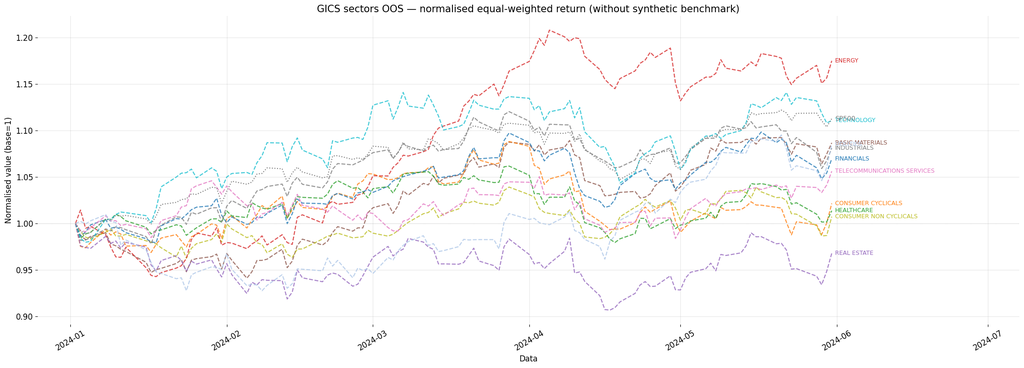

**Market context without the Synthetic Benchmark**

The same view as the previous chart, but without the synthetic envelope: the dominant black line is removed to expose the dispersion across the 11 GICS sectors and the relative position of the SP500 (grey dotted). Without the envelope it is easier to read which sectors lead in each stretch of the OOS period — information that the previous chart compresses visually behind the black Synthetic Benchmark line.

```
[INFO]: Plot saved → /media/toni/Dados/Git/ssd-multi/src/output/tafmssd-sectors/en/market_context_basic_materials.pdf
```

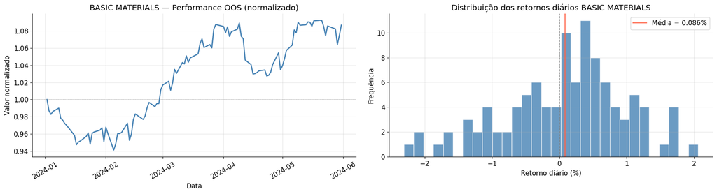

```
[INFO]: Plot saved → /media/toni/Dados/Git/ssd-multi/src/output/tafmssd-sectors/en/market_context_consumer_cyclicals.pdf
```

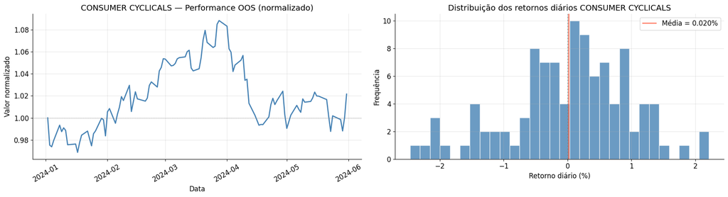

```
[INFO]: Plot saved → /media/toni/Dados/Git/ssd-multi/src/output/tafmssd-sectors/en/market_context_consumer_non_cyclicals.pdf
```

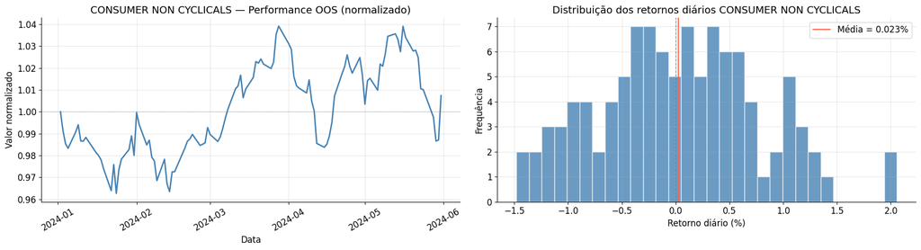

```
[INFO]: Plot saved → /media/toni/Dados/Git/ssd-multi/src/output/tafmssd-sectors/en/market_context_energy.pdf
```

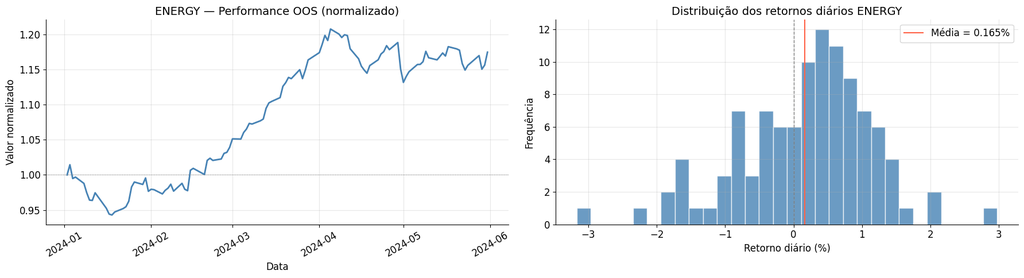

```
[INFO]: Plot saved → /media/toni/Dados/Git/ssd-multi/src/output/tafmssd-sectors/en/market_context_financials.pdf
```

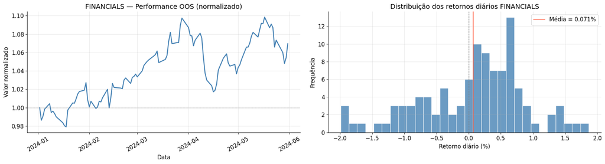

```
[INFO]: Plot saved → /media/toni/Dados/Git/ssd-multi/src/output/tafmssd-sectors/en/market_context_healthcare.pdf
```

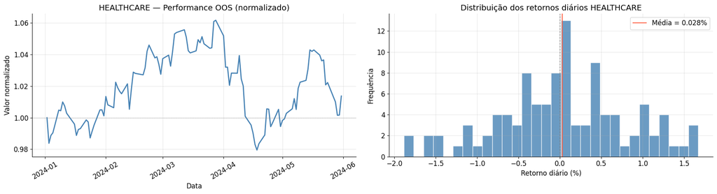

```
[INFO]: Plot saved → /media/toni/Dados/Git/ssd-multi/src/output/tafmssd-sectors/en/market_context_industrials.pdf
```

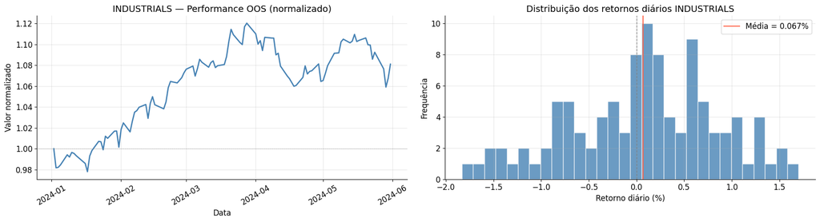

```
[INFO]: Plot saved → /media/toni/Dados/Git/ssd-multi/src/output/tafmssd-sectors/en/market_context_real_estate.pdf
```

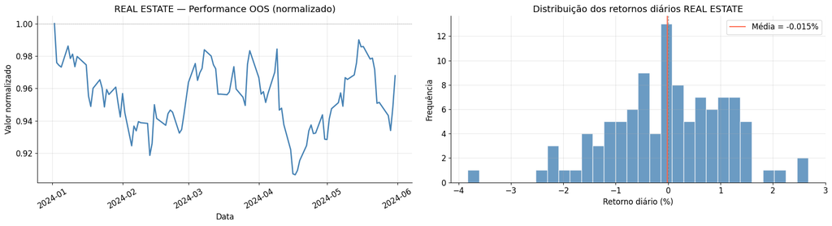

```
[INFO]: Plot saved → /media/toni/Dados/Git/ssd-multi/src/output/tafmssd-sectors/en/market_context_technology.pdf
```

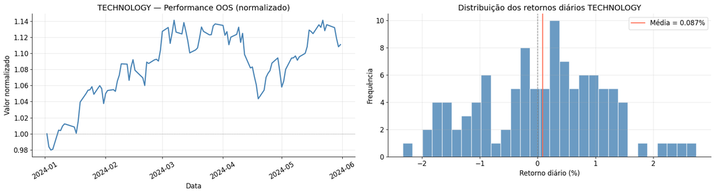

```
[INFO]: Plot saved → /media/toni/Dados/Git/ssd-multi/src/output/tafmssd-sectors/en/market_context_telecommunications_services.pdf
```

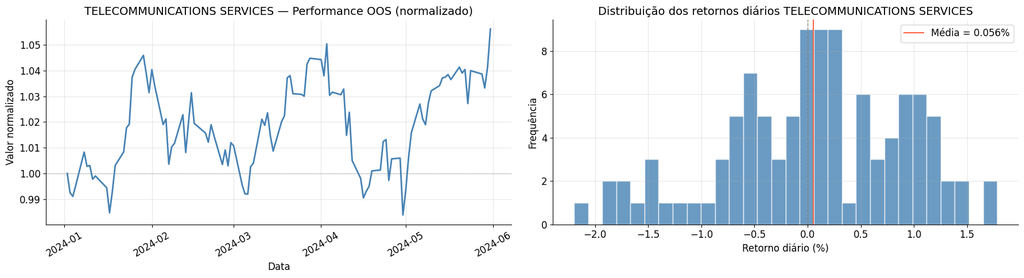

```
[INFO]: Plot saved → /media/toni/Dados/Git/ssd-multi/src/output/tafmssd-sectors/en/market_context_utilities.pdf
```

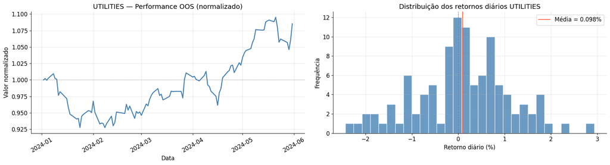

**Individual market context per sector**

Each panel combines the normalised series with the distribution of a sector's daily returns. Sectors with wide return tails create the most demanding SSD constraints: the portfolio must accumulate sufficient returns even in that sector's worst scenarios, so that the cumulative integral of the portfolio's sorted returns dominates the sector's corresponding integral. Sectors with a pronounced upward trend over the OOS period are the most likely candidates to have been the Synthetic Benchmark's binding constraint in some training window. Sectors with persistently negative returns (series below 1.0) were rarely binding — the portfolio dominated them by a wide margin, leaving their SSD constraints virtually inactive during the optimisation.

## 3b. Dominant sector per OOS day

```
Daily dominance frequency (which sector has the highest return on each OOS day):
  ENERGY                                   23 days  (21.9%)
  TECHNOLOGY                               22 days  (21.0%)
  UTILITIES                                16 days  (15.2%)
  CONSUMER_NON_CYCLICALS                    9 days  (8.6%)
  CONSUMER_CYCLICALS                        8 days  (7.6%)
  REAL_ESTATE                               8 days  (7.6%)
  BASIC_MATERIALS                           6 days  (5.7%)
  FINANCIALS                                5 days  (4.8%)
  TELECOMMUNICATIONS_SERVICES               4 days  (3.8%)
  HEALTHCARE                                3 days  (2.9%)
  INDUSTRIALS                               1 days  (1.0%)
```

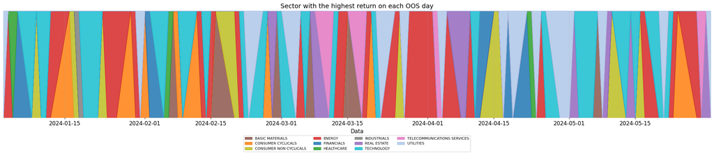

**Dominant sector per OOS day**

## 4. OOS synthetic benchmark — detailed analysis

The OOS synthetic benchmark uses the same formulation as in sample:

$$\tau_{\text{oos}}[s] \;=\; \max_k\Bigl(\mathrm{Tail}_{s/S^k}\bigl(I^k\bigr)\Bigr)$$

computed over the OOS sector returns. The implied returns — the first difference of $S\cdot\tau$ — are dated by *quantile matching* against the cross-sector mean return.

In sample, $\tau_{\text{synth}}$ and the implied per-rank returns are recorded at every rebalancing window.

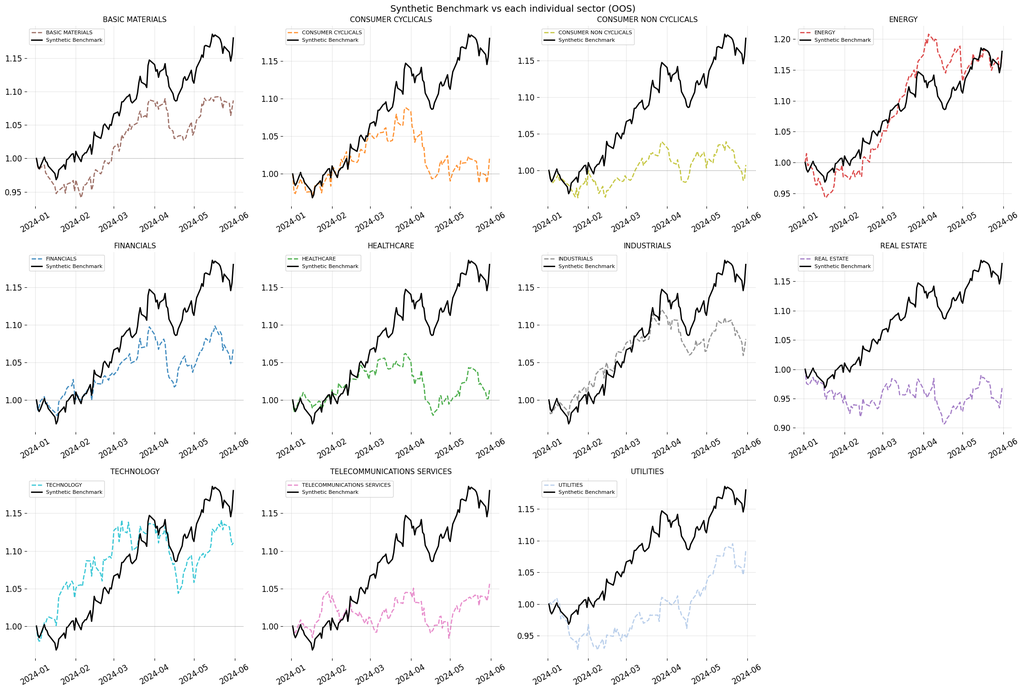

**Synthetic Benchmark vs each individual sector**

Each panel makes explicit the "slack" the model had to cover in order to guarantee SSD dominance: the vertical distance between the Synthetic Benchmark (black) and the individual sector (coloured) represents how far that sector fell below the synthetic benchmark at each point in time. Panels where the sector hugs the Synthetic Benchmark identify the model's binding constraints — sectors that frequently set the level of the LP constraint and therefore had the greatest influence on portfolio composition. Sectors far below the Synthetic Benchmark were rarely binding and the model dominated them with a comfortable margin. The shape of the Synthetic Benchmark curve is especially informative: an upward trajectory concentrated in the first OOS days implies in-sample constraints calibrated for early gains, whereas a curve rising at the end indicates that the most demanding scenario only materialised as the period closed.

```
5 training windows found
```

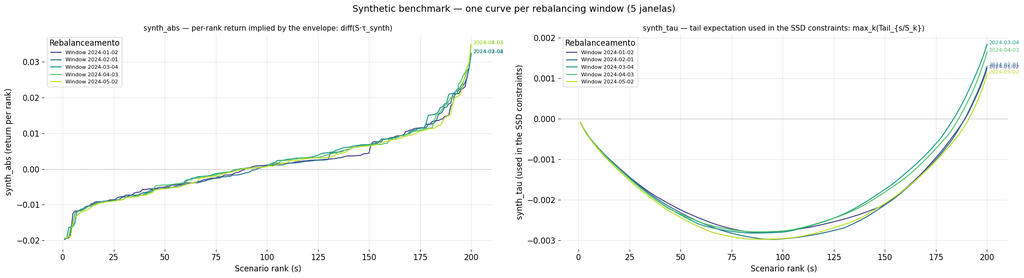

**Synthetic Benchmark per rebalancing window (absolute and cumulative curves)**

> **Reading the figure.** Each curve corresponds to **one rebalancing window** — there are 5, one per rebalancing date — and **not** to a sector. The synthetic benchmark of each window is already the envelope over the 11 sectors of that window; the 11 sector curves that compose it appear individually in the *Constraint tightness* section below. The previous label ("sectorial synthetic bench") invited the wrong reading that each curve was a sector.

The left panel (`synth_abs`) shows the per-rank return implied by the synthetic envelope (the first difference of the cumulative $S\cdot\tau_{\text{synth}}$) — from the worst to the best scenario within the training window. The right panel (`synth_tau`) displays the unconditional tail expectation,

$$\tau_{\text{synth}}[s] \;=\; \max_k\bigl(\mathrm{Tail}_{s/S^k}\bigr),$$

which enters the LP's SSD constraints directly. Curves that lie close together across distinct windows (overlapping viridis colours) indicate that the Synthetic Benchmark is stable over time, which favours consistency of the constraints at each rebalancing. The zero-crossing point in `synth_abs` marks the boundary between loss and gain scenarios: a late crossing (many negative ranks) means that the Synthetic Benchmark's worst scenarios concentrate significant losses, imposing very demanding constraints on the negative tails. The slope of `synth_tau` in the region of the worst ranks determines the "hardness" of the SSD constraints that are most difficult to satisfy — windows with a steep slope force the portfolio to hold a larger reserve of cumulative returns in downside scenarios. Divergence across windows indicates qualitatively distinct market periods that produced different constraint structures for the solver.

## 5. Constraint tightness — $\tau_k$ per sector per training window

For each sector $k$, the unconditional expectation of the $s$ worst returns is

$$\tau_k[s] \;=\; \mathrm{Tail}_{s/S^k}\bigl(I^k\bigr) \;=\; \frac{1}{S^k}\sum_{i=1}^{s} r^{(i)}_k ,$$

where $r^{(i)}_k$ is the $i$-th smallest return of sector $k$ within the window. The binding constraint at each rank $s$ is the upper envelope across sectors:

$$\tau_{\text{synth}}[s] \;=\; \max_k\bigl(\tau_k[s]\bigr).$$

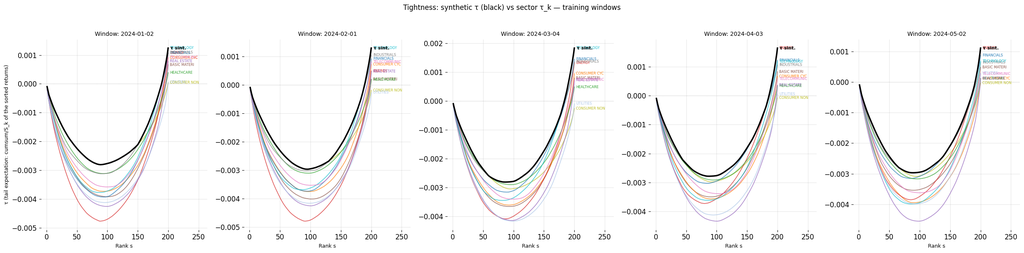

**Constraint tightness: $\tau_k$ per sector per training window**

For each training window,

$$\tau_k[s] \;=\; \mathrm{Tail}_{s/S^k}\bigl(I^k\bigr) \qquad\text{and}\qquad \tau_{\text{synth}}[s] \;=\; \max_k\bigl(\tau_k[s]\bigr),$$

that is: $\tau_k[s]$ is the unconditional expectation of the $s$ worst returns of sector $k$, and $\tau_{\text{synth}}$ is the upper envelope that determines the LP's effective constraints. A narrow gap between $\tau_{\text{synth}}$ and a particular sector indicates that this sector was the binding constraint for the corresponding ranks: small variations in its returns would shift the constraint level. How the gap varies across ranks reveals whether a given sector is binding only in the tails (worst scenarios) or across the whole distribution — relevant information for understanding where the model concentrated its optimisation "effort". $\tau_{\text{synth}}$ inevitably takes negative values at the first ranks (the average of the worst returns), but the magnitude of that negativity matters: a strongly negative $\tau_{\text{synth}}$ in the tails makes the SSD constraints of the worst scenarios nearly insurmountable without sacrificing the middle ranks. Abrupt changes in $\tau_{\text{synth}}$ between consecutive windows signal instability in the constraints, which may translate into high portfolio turnover at each rebalancing.

## 6. Dominant sector per rank — which sector is binding at each rank s?

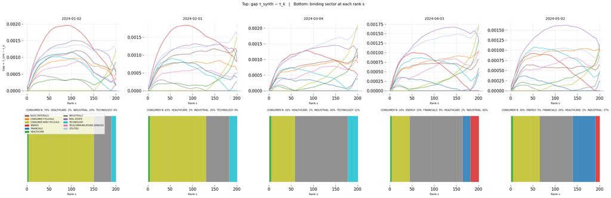

**Dominant sector per rank s (which sector is binding at each rank)**

The upper panel (gap $\tau_{\text{synth}} - \tau_k$) and the lower panel (binding sector at each rank) reveal the internal structure of the Synthetic Benchmark in each training window. When the lower colour panel shows a single sector dominating most ranks (wide blocks of a single colour), the Synthetic Benchmark is effectively single-sector for that window — in practice equivalent to optimising against that sector alone. High fragmentation indicates a genuinely multi-sector Synthetic Benchmark: the portfolio must simultaneously defend itself against one sector's worst scenarios and another sector's best scenarios, making the optimisation problem more complex. When several sectors compete for the binding position at the same rank (a small gap for several sectors at once), the Synthetic Benchmark is especially "hard" in that region of the distribution. Finally, changes in the dominant sector between consecutive windows explain abrupt shifts in portfolio composition: when rebalancing, the solver is reacting to a qualitatively different constraint structure.

```
Percentage of ranks s where each sector is binding (argmax of τ), per window:
```

| Window | CONSUMER_NON_CYCLICALS | ENERGY | FINANCIALS | HEALTHCARE | INDUSTRIALS | TECHNOLOGY | n_binding_sectors |
| --- | --- | --- | --- | --- | --- | --- | --- |
| 2024-01-02 | 73.5 | 0.0 | 0.0 | 1.5 | 19.5 | 5.5 | 4 |
| 2024-02-01 | 63.0 | 0.0 | 0.0 | 2.0 | 26.0 | 9.0 | 4 |
| 2024-03-04 | 26.5 | 0.0 | 0.0 | 2.5 | 59.5 | 11.5 | 4 |
| 2024-04-03 | 20.0 | 9.5 | 9.0 | 2.0 | 59.5 | 0.0 | 5 |
| 2024-05-02 | 30.5 | 5.0 | 25.5 | 2.0 | 37.0 | 0.0 | 5 |

```
Sectors binding in at least one window: 6 of 11 → Consumer Non Cyclicals, Energy, Financials, Healthcare, Industrials, Technology
Maximum number of binding sectors in a single window: 5
```

**Binding sector per rank — numerical summary**

### Synthetic benchmark vs. ENERGY — coincidence check

The **Energy** sector has the most asymmetric distribution in the panel, and the hypothesis raised was that the synthetic benchmark would sit *almost always* right on top of it, possibly even coinciding with it. If it did coincide, the synthetic envelope would be redundant — optimising against Energy alone would suffice. The two panels below test this directly: on the left, $\tau_{\text{synth}}$ against $\tau_{\text{ENERGY}}$ rank by rank in each training window; on the right, the normalised out-of-sample series. The gap $\tau_{\text{synth}} - \tau_{\text{ENERGY}} \geq 0$ by construction; being identically zero would mean exact coincidence.

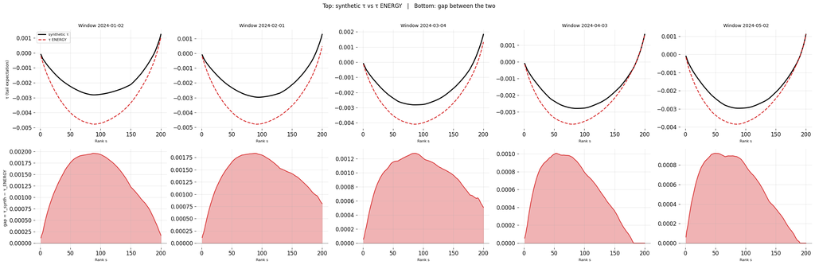

| Window | % ranks ENERGY binding | mean gap | max gap | coincides (gap≈0) |
| --- | --- | --- | --- | --- |
| 2024-01-02 | 0.0 | 1.363e-03 | 1.964e-03 | False |
| 2024-02-01 | 0.0 | 1.398e-03 | 1.837e-03 | False |
| 2024-03-04 | 0.0 | 9.550e-04 | 1.278e-03 | False |
| 2024-04-03 | 9.5 | 5.841e-04 | 1.006e-03 | False |
| 2024-05-02 | 5.0 | 5.638e-04 | 9.194e-04 | False |

```
Does the synthetic benchmark coincide exactly with ENERGY in every window? NO
ENERGY is binding, on average, at 2.9% of the ranks.
```

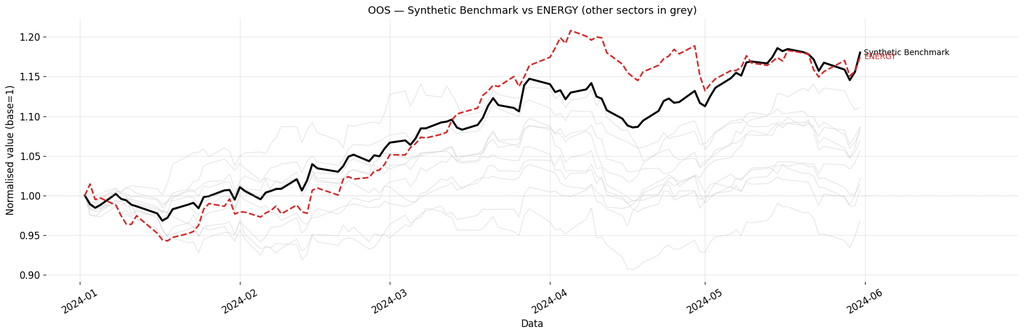

```
OOS correlation between synthetic and ENERGY returns: 0.5569
```

**Synthetic × ENERGY — reading**

## 7. Overview — portfolio vs sectors

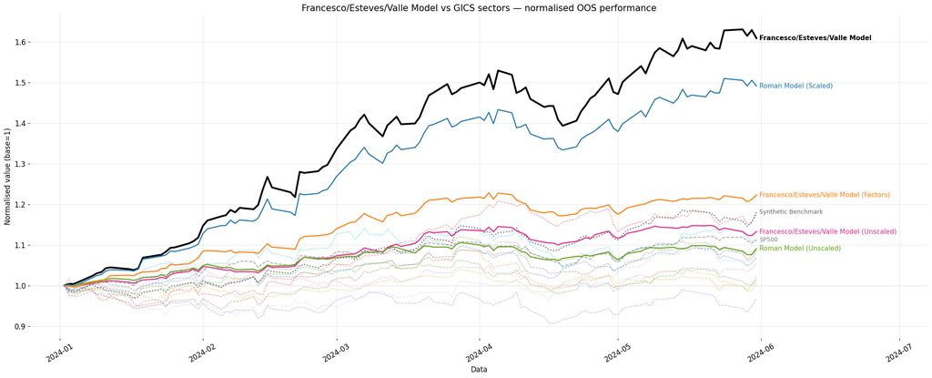

**Overview: portfolio vs GICS sectors**

## 8. Comparative drawdown

### Drawdown definition

Drawdown is measured on the **normalised** wealth series $W_t$ (base 1 at the start of the OOS period), as the relative fall from the running peak:

$$DD_t \;=\; \frac{W_t - \max_{u \le t} W_u}{\max_{u \le t} W_u}$$

The panel was redone relative to v1: the two charts now share the $y$-axis scale, which allows a direct comparison between the depth of the sectors' and the portfolios' falls, and the maximum drawdown point of each series in the lower panel is marked explicitly.

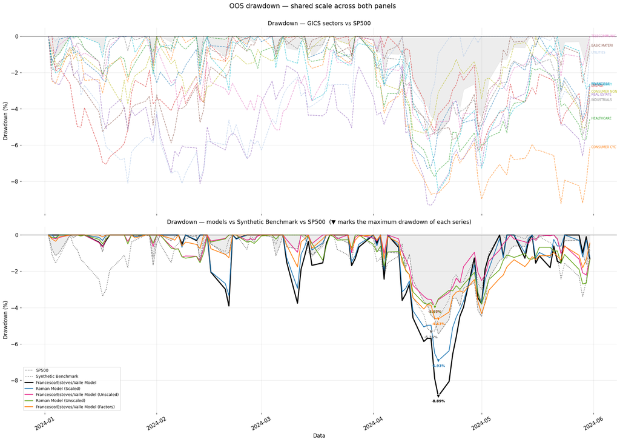

```
Maximum OOS drawdown (less negative = better):

  Francesco/Esteves/Valle Model (Unscaled)         -3.95%
  Roman Model (Unscaled)                           -3.97%
  Francesco/Esteves/Valle Model (Factors)          -4.63%
  Synthetic Benchmark                              -5.35%
  Roman Model (Scaled)                             -6.93%
  Francesco/Esteves/Valle Model                    -8.89%
```

**Comparative drawdown**

The upper panel shows the drawdown of the 11 GICS sectors against the SP500; the lower panel, that of the models. With the $y$-axis scale now shared, the comparison between the two is direct: one can see immediately whether the optimised portfolio suffers falls of the same order of magnitude as the sectors that make up its benchmark, or whether the SSD optimisation effectively dampens the tails. The ▼ markers indicate the timing and depth of each series' maximum drawdown — the value reported in the `Max Drawdown (%)` column of the metrics table.

The relevant reading is the *shape* of the recovery, not only its depth: two portfolios with the same maximum drawdown are very different if one regains its peak within days and the other stays underwater for weeks. SSD constraints act on the unconditional distribution of returns and impose nothing on temporal ordering, so nothing guarantees a fast recovery — drawdown is precisely the metric that exposes the dimension the optimisation criterion does not control.

## 9. OOS metrics — full table

### Metrics — definitions

All metrics start from the normalised wealth series $W_t$ (base 1) and the daily returns $r_t = W_t/W_{t-1} - 1$, with $T$ observations and $r_f$ the annual risk-free rate.

| Metric | Formula |
| --- | --- |
| **CAGR** | $\left(\dfrac{W_T}{W_0}\right)^{252/T} - 1$ — geometric growth rate, equivalent to the annualised geometric mean of returns |
| **Mean return** | $\bar{r} \cdot 252$ — annualised arithmetic mean; the **common numerator** of Sharpe and Sortino |
| **Volatility** | $\sigma(r) \cdot \sqrt{252}$ |
| **Semi-volatility** | $\sqrt{\mathbb{E}\left[\min(r_t, 0)^2\right]} \cdot \sqrt{252}$ — semideviation below a zero target, penalising the downside only |
| **Sharpe** | $\dfrac{\bar{r}\cdot 252 - r_f}{\sigma(r)\sqrt{252}}$ |
| **Sortino** | $\dfrac{\bar{r}\cdot 252 - r_f}{\text{semi-volatility}}$ — same numerator as Sharpe, risk measured on the downside only |
| **Calmar** | $\dfrac{\text{CAGR}}{\lvert \mathrm{MDD}\rvert}$ — return per unit of maximum loss |
| **Daily CVaR 5%** | $\mathbb{E}\left[r_t \mid r_t \le q_{0.05}(r)\right]$, reported as a positive loss |
| **Max Drawdown** | $\min_t DD_t$ (definition in the previous section), **negative** |
| **Beta** | $\dfrac{\mathrm{Cov}(r, r_{\text{SP500}})}{\mathrm{Var}(r_{\text{SP500}})}$ — always **against the SP500** |

**What changed relative to v1:**

1. **Sharpe and Sortino now share the numerator.** In v1 the Sharpe used the arithmetic mean of returns while the Sortino used the CAGR — different quantities, which made the two indices mutually incomparable. The `Mean return (%)` column makes this common numerator explicit.
2. **Semi-volatility proper.** v1 used the standard deviation of the negative returns; it is now the semideviation $\sqrt{\mathbb{E}[\min(r,0)^2]}$, with the squared shortfalls averaged over *all* scenarios. This makes it directly comparable to full volatility — and it is the appropriate measure for asymmetric distributions such as those of the sectors analysed here.
3. **Max Drawdown colours corrected.** In v1 the column entered the same inverted gradient as volatility and CVaR. Since Max Drawdown is negative, this painted the worst value (the most negative) green and the best one red. It now uses the direct gradient.
4. **Stochastic dominance as a number**, not only as a figure — columns described below.

**Dominance columns (vs. Synthetic Benchmark).** With $r_{P,(s)}$ and $r_{B,(s)}$ the sorted returns of the portfolio and of the benchmark,

$$\mathrm{SSD}_s \;=\; \sum_{z\le s}\left(r_{P,(z)} - r_{B,(z)}\right):$$

- `min SSD` — the minimum of the SSD curve. If $\ge 0$, there is **second-order stochastic dominance**.
- `% ranks SSD≥0` — the fraction of ranks where the condition holds; 100% ⟺ full dominance.
- `Violation area` — $\frac{1}{S}\sum_s \min(\mathrm{SSD}_s, 0)$, the average magnitude of the violation. Zero ⟺ dominance; the more negative, the further from dominating.

|  | Final value | CAGR (%) | Mean return (%) | Volatility (%) | Semi-volatility (%) | Daily CVaR 5% (%) | Sharpe Ratio | Sortino Ratio | Calmar Ratio | Max Drawdown (%) | Beta vs SP500 | min SSD | % ranks SSD>=0 | Violation area |
| --- | --- | --- | --- | --- | --- | --- | --- | --- | --- | --- | --- | --- | --- | --- |
| SP500 | 1.1127 | 29.5400 | 26.5300 | 11.3400 | 7.1200 | 1.4070 | 1.8990 | 3.0252 | 5.4062 | -5.4600 | 1.0000 | -6.024e-02 | 69.2 | -5.042e-03 |
| Synthetic Benchmark | 1.1802 | 49.3900 | 41.1300 | 13.9100 | 7.9700 | 1.3310 | 2.5979 | 4.5333 | 9.2329 | -5.3500 | 0.9013 | 0.000e+00 | 100.0 | 0.000e+00 |
| Francesco/Esteves/Valle Model | 1.6089 | 216.5500 | 117.9000 | 22.0700 | 12.0900 | 2.3830 | 5.1149 | 9.3418 | 24.3688 | -8.8900 | 1.1691 | -1.158e-01 | 50.0 | -3.645e-02 |
| Roman Model (Scaled) | 1.4911 | 163.2900 | 98.6400 | 18.2900 | 9.7600 | 1.9300 | 5.1194 | 9.5920 | 23.5625 | -6.9300 | 1.0043 | -5.157e-02 | 63.5 | -1.304e-02 |
| Francesco/Esteves/Valle Model (Unscaled) | 1.1327 | 35.2400 | 30.5800 | 8.6200 | 5.0400 | 0.9490 | 2.9685 | 5.0751 | 8.9150 | -3.9500 | 0.5443 | -4.355e-02 | 94.2 | -9.998e-04 |
| Roman Model (Unscaled) | 1.0907 | 23.4100 | 21.3700 | 8.0700 | 5.0500 | 0.9700 | 2.0292 | 3.2414 | 5.9008 | -3.9700 | 0.4801 | -8.155e-02 | 88.5 | -4.101e-03 |
| Francesco/Esteves/Valle Model (Factors) | 1.2230 | 62.8800 | 49.3500 | 10.2900 | 5.7100 | 1.1700 | 4.3107 | 7.7708 | 13.5732 | -4.6300 | 0.6071 | 1.545e-03 | 100.0 | 0.000e+00 |
| BASIC MATERIALS | 1.0867 | 22.3300 | 21.2000 | 14.4600 | 10.1100 | 1.9300 | 1.1205 | 1.6014 | 3.7919 | -5.8900 | 0.7860 | -8.226e-02 | 0.0 | -4.891e-02 |
| CONSUMER CYCLICALS | 1.0215 | 5.3000 | 6.3400 | 15.3700 | 11.3000 | 2.1660 | 0.0871 | 0.1184 | 0.5743 | -9.2300 | 1.0009 | -1.436e-01 | 0.0 | -9.472e-02 |
| CONSUMER NON CYCLICALS | 1.0073 | 1.7900 | 2.4500 | 11.7300 | 7.9800 | 1.3310 | -0.2173 | -0.3191 | 0.3350 | -5.3400 | 0.3211 | -1.596e-01 | 41.3 | -4.005e-02 |
| ENERGY | 1.1750 | 47.8000 | 40.3400 | 15.8100 | 10.7200 | 2.0990 | 2.2360 | 3.2962 | 6.7687 | -7.0600 | 0.5442 | -6.916e-02 | 0.0 | -2.819e-02 |
| FINANCIALS | 1.0696 | 17.7000 | 17.1400 | 13.0200 | 9.3100 | 1.7820 | 0.9329 | 1.3045 | 2.4239 | -7.3000 | 0.6215 | -9.899e-02 | 0.0 | -2.890e-02 |
| HEALTHCARE | 1.0137 | 3.3600 | 4.0500 | 12.3200 | 8.6800 | 1.6520 | -0.0769 | -0.1091 | 0.4332 | -7.7500 | 0.7289 | -1.530e-01 | 0.0 | -4.603e-02 |
| INDUSTRIALS | 1.0810 | 20.7800 | 19.6500 | 12.4200 | 8.4700 | 1.5730 | 1.1799 | 1.7301 | 3.8006 | -5.4700 | 0.8723 | -8.864e-02 | 26.0 | -1.904e-02 |
| REAL ESTATE | 0.9679 | -7.6000 | -6.3200 | 17.8400 | 13.2500 | 2.4320 | -0.6346 | -0.8544 | -0.8156 | -9.3200 | 0.8943 | -2.139e-01 | 0.0 | -1.675e-01 |
| TECHNOLOGY | 1.1108 | 28.9800 | 26.8600 | 16.7900 | 11.1300 | 1.8580 | 1.3023 | 1.9635 | 3.3913 | -8.5500 | 1.3156 | -1.052e-01 | 0.0 | -8.290e-02 |
| TELECOMMUNICATIONS SERVICES | 1.0562 | 14.1600 | 14.2000 | 13.8300 | 9.7600 | 1.8280 | 0.6652 | 0.9420 | 2.2343 | -6.3400 | 0.7683 | -1.111e-01 | 0.0 | -5.358e-02 |
| UTILITIES | 1.0853 | 21.9400 | 21.1200 | 16.0700 | 10.7700 | 2.0310 | 1.0031 | 1.4972 | 2.7040 | -8.1100 | 0.3576 | -1.085e-01 | 0.0 | -7.711e-02 |

**OOS metrics (full table)**

The return columns, the risk-adjusted ratios and the drawdown are defined in the previous section. Two readings are of particular interest:

**Volatility vs. semi-volatility.** The more profitable models carry, as expected, more total risk. The comparison between the two columns is what separates *loss* risk from mere oscillation: a series with high volatility but proportionally low semi-volatility is oscillating mostly upwards — a favourable asymmetry that full volatility penalises unduly. This is why the Sortino ratio, which shares its numerator with the Sharpe and only changes the denominator, tends to separate the models here better than the Sharpe does.

**Dominance vs. Synthetic Benchmark.** The SSD constraint is imposed *in sample*, on the training window; these columns measure whether it holds *out of sample*, where there is no theoretical guarantee. A series with `% ranks SSD≥0` equal to 100% dominates the synthetic benchmark over the OOS period. Intermediate values with a `Violation area` close to zero indicate marginal violations concentrated in a few ranks — a materially different situation from a deep, systematic violation.

## 10. SSD dominance

```
Francesco/Esteves/Valle Model vs Synthetic Benchmark: min(SSD) = -0.115770  ✗ VIOLA
Roman Model (Scaled) vs SP500: min(SSD) = -0.074537  ✗ VIOLA
Francesco/Esteves/Valle Model (Unscaled) vs Synthetic Benchmark: min(SSD) = -0.043552  ✗ VIOLA
Roman Model (Unscaled) vs SP500: min(SSD) = -0.021319  ✗ VIOLA
Francesco/Esteves/Valle Model (Factors) vs SP500: min(SSD) = +0.002830  ✓ DOMINA
```

```
[INFO]: Plot saved → /media/toni/Dados/Git/ssd-multi/src/output/tafmssd-sectors/en/ssd_home_dominance.pdf
```

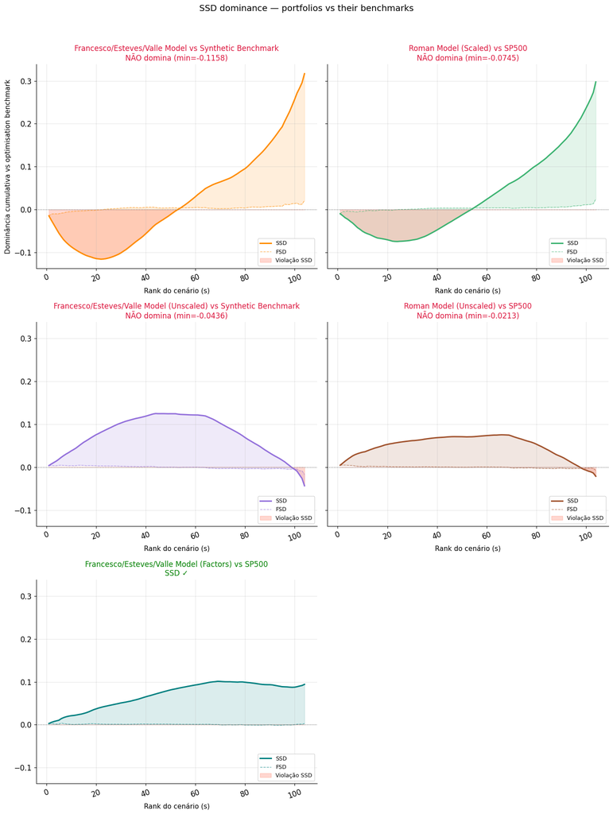

**SSD dominance: portfolios vs their optimisation benchmarks**

This panel checks whether each portfolio SSD-dominates its own optimisation benchmark over the OOS period. In-sample SSD dominance is guaranteed by the LP — what is tested here is generalisation. For the Francesco/Esteves/Valle Model, the SSD curve must be ≥ 0 at every point to confirm OOS dominance against the sector Synthetic Benchmark; violations (negative regions) pinpoint exactly where the benchmark outperformed the portfolio in the cumulative distribution. Violations in the left tails (worst scenarios) are the most concerning, since they indicate that the portfolio lost more than the benchmark on the worst OOS days — contradicting the fundamental objective of the formulation. Mild violations (min SSD close to zero) are acceptable given the temporal gap between the in-sample and OOS periods. The comparison with the Roman Model (Scaled) vs SP500 provides the baseline: if the sector model shows OOS dominance similar to or better than the Roman Model, using sector benchmarks adds value without degrading the dominance property.

```
=== Francesco/Esteves/Valle Model: cross-dominance vs each sector ===
  Sector                                    min(SSD)    min(FSD)  Status
  ------------------------------------------------------------------------
  BASIC_MATERIALS                          -0.057552   -0.006333  ✗ VIOLA
  CONSUMER_CYCLICALS                       -0.026649   -0.004765  ✗ VIOLA
  CONSUMER_NON_CYCLICALS                   -0.115770   -0.014613  ✗ VIOLA
  ENERGY                                   -0.047126   -0.005627  ✗ VIOLA
  FINANCIALS                               -0.078432   -0.009530  ✗ VIOLA
  HEALTHCARE                               -0.100124   -0.010578  ✗ VIOLA
  INDUSTRIALS                              -0.100464   -0.011128  ✗ VIOLA
  REAL_ESTATE                              +0.000250   -0.002238  ✓ DOMINA
  TECHNOLOGY                               -0.035246   -0.006119  ✗ VIOLA
  TELECOMMUNICATIONS_SERVICES              -0.072064   -0.007440  ✗ VIOLA
  UTILITIES                                -0.038905   -0.005088  ✗ VIOLA
```

```
[INFO]: Plot saved → /media/toni/Dados/Git/ssd-multi/src/output/tafmssd-sectors/en/ssd_cross_dominance_sectors.pdf
```

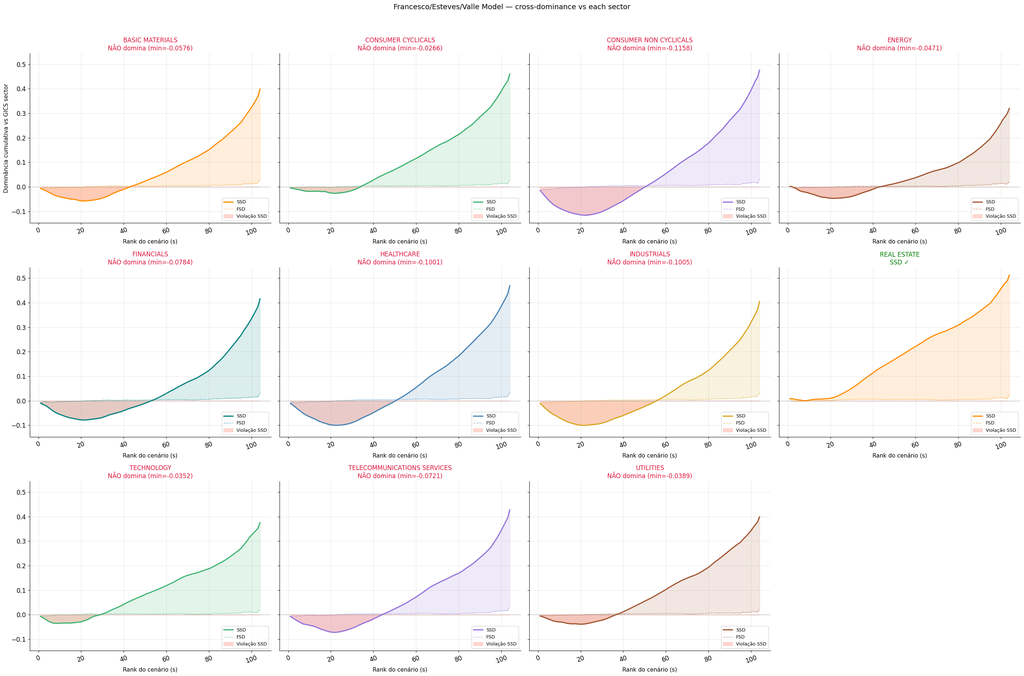

**Cross-dominance: Francesco/Esteves/Valle Model vs each sector individually**

## 10b. SSD dominance — CDFs and cumulative integrals (scaled × unscaled grid)

For each model in the 2×2 grid, $F(x)$ (the portfolio's CDF) is compared with $G(x)$ (the CDF of the benchmark it was optimised against — the sector synthetic benchmark for this work's models, the SP500 for Rome's):

- **Green**: $G \ge F$ → the portfolio dominates in that region
- **Pink**: $G < F$ → the benchmark dominates in that region
- **$I_2(x)$**: the left-cumulative integral of $G-F$. The second-order dominance condition is

$$I_2(x) \;=\; \int_{-\infty}^{x}\bigl[G(u) - F(u)\bigr]\,du \;\ge\; 0 \quad \forall x .$$

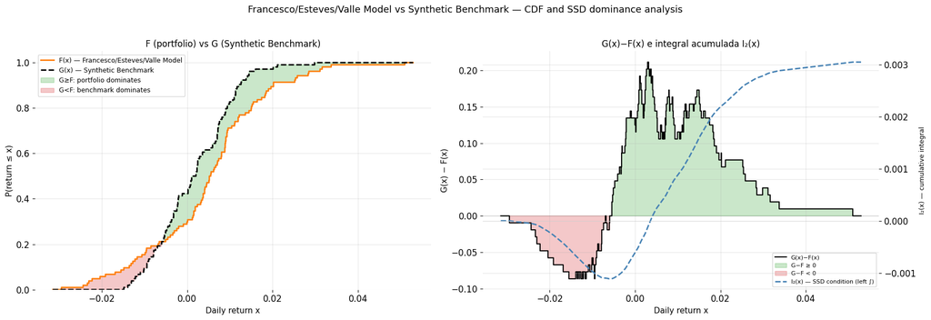

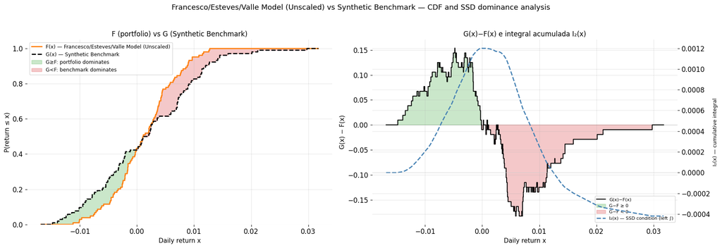

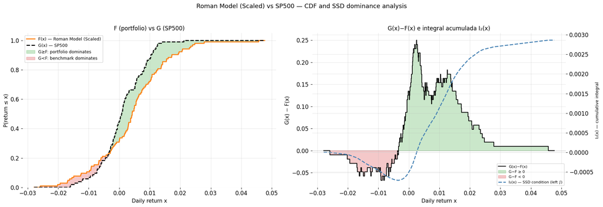

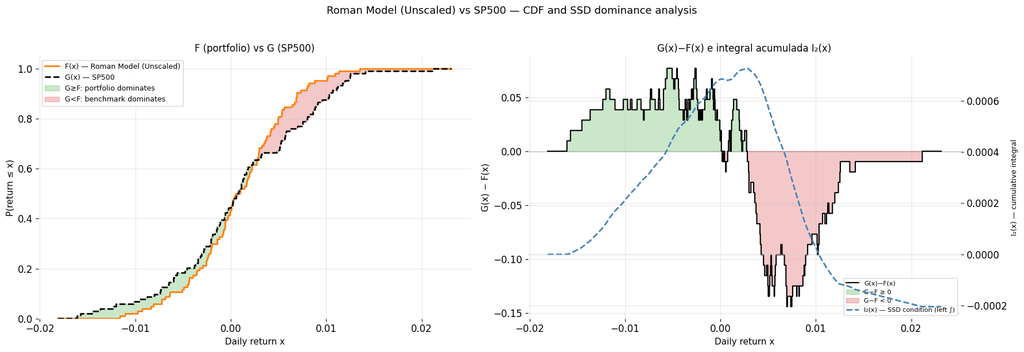

```
min I₂(x) — negative indicates where SSD dominance did not carry over out of sample:
  Francesco/Esteves/Valle Model vs Synthetic Benchmark       -1.113e-03  ✗ violates
  Francesco/Esteves/Valle Model (Unscaled) vs Synthetic Benchmark -4.199e-04  ✗ violates
  Roman Model (Scaled) vs SP500                              -7.150e-04  ✗ violates
  Roman Model (Unscaled) vs SP500                            -2.040e-04  ✗ violates
```

**CDFs and the SSD integral — the four models of the grid**

The left panel of each figure overlays the empirical CDFs of the portfolio, $F(x)$, and of its benchmark, $G(x)$. Green marks $G \ge F$ (the portfolio has a lower probability of falling below $x$ — an advantage for the portfolio in that range) and pink marks $G < F$. The right panel shows $G-F$ and the cumulative integral $I_2(x)$, whose non-negativity over all $x$ is a necessary and sufficient condition for SSD dominance.

**The scaled/unscaled axis flips the shape of the curve — and the type of failure.**

|  | where the portfolio has the advantage | where $I_2$ attains its minimum | min $I_2$ |
| --- | --- | --- | --- |
| FEV Model (scaled) | **right** tail (gains) | **left** tail | $-1.11\times10^{-3}$ |
| FEV Model (unscaled) | **left** tail (losses) | far **right** | $-4.20\times10^{-4}$ |
| Roman (scaled) | **right** tail | **left** tail | $-7.15\times10^{-4}$ |
| Roman (unscaled) | **left** tail | far **right** | $-2.04\times10^{-4}$ |

The *scaled* models are pink on the left and green on the right: they lose to the benchmark in the loss region and win in the gain region. The *unscaled* models do the opposite. This is the same dichotomy observed in section 14d — the *scaled* model concentrates in aggressive assets, the *unscaled* one diversifies and protects the downside — now seen over the entire distribution rather than only through summary statistics.

**Take care when comparing the `min` $I_2$ across the two families: they measure failures of a different nature.** Since $I_2(x) \to \mathbb{E}[r_P] - \mathbb{E}[r_B]$ as $x \to +\infty$, the value at the far right is simply the difference in mean return. In the *unscaled* models the minimum of $I_2$ lies exactly there: the violation says that **the portfolio returns less than the benchmark on average** (1.133 against 1.180 for the synthetic benchmark; 1.091 against 1.113 for the SP500), not that it is risky. In the *scaled* models the minimum lies in the left tail — a **downside protection** violation — even though $I_2$ ends clearly positive, reflecting the much higher mean return.

In other words: the smaller `min` $I_2$ of the *unscaled* models does **not** make them preferable. A violation at the far right is a return shortfall; a violation in the left tail is exposure to losses. Which of the two is acceptable depends on the investor's profile — precisely the point Francesco raised at the meeting (min 35:50) about sectors for the risk-seeking investor and factors for the conservative one.

## 10c. r_P vs r_B by quantile — tail analysis (Francesco/Esteves/Valle Model)

For each quantile threshold, the OOS days are split into:

- **Benchmark's worst days (blue)**: the k days with the lowest benchmark returns → measures downside protection
- **Benchmark's best days (orange)**: the remaining days → measures upside capture

The β of each regression measures the sensitivity of the portfolio's return to the benchmark in that region. The portfolio is compared against the sector **Synthetic Benchmark**, which is its optimisation benchmark.

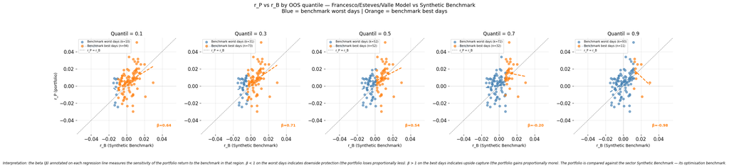

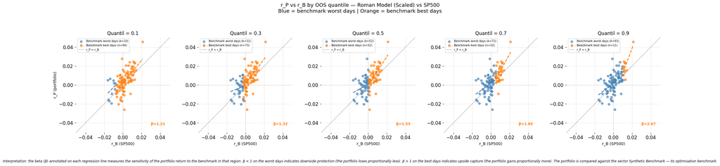

**r_P vs r_B by quantile: tail analysis**

For each quantile threshold, the OOS days are split into the "benchmark's worst days" (blue) and the "benchmark's best days" (orange). The slope β of each regression measures the portfolio's sensitivity to the benchmark in that region of the distribution. For the Francesco/Esteves/Valle Model vs the Synthetic Benchmark, β < 1 on the worst days is the most direct evidence of downside protection: the portfolio falls proportionally less when the Synthetic Benchmark falls, consistent with the SSD constraint on the negative tails of the in-sample distribution. β on the best days tends to be ≈ 1 or lower — SSD optimisation includes no upside incentive, so a low β here is the expected cost of the pure SSD approach, not a failure. High scatter of the points indicates that the portfolio is independent of the Synthetic Benchmark on a day-to-day basis, which is expected given that the optimisation is distributional (over the empirical distribution) rather than daily. If the blue β increases as the quantile moves from 10% to 50%, downside protection is stronger in the extreme tails — exactly where it is most valuable. The Roman Model (Scaled) vs SP500 comparison provides the baseline for assessing whether the nature of the benchmark — sector-based vs market index — changes the tail behaviour.

## 11. Risk × return analysis

```
[INFO]: Plot saved → /media/toni/Dados/Git/ssd-multi/src/output/tafmssd-sectors/en/risk_return_all.pdf
```

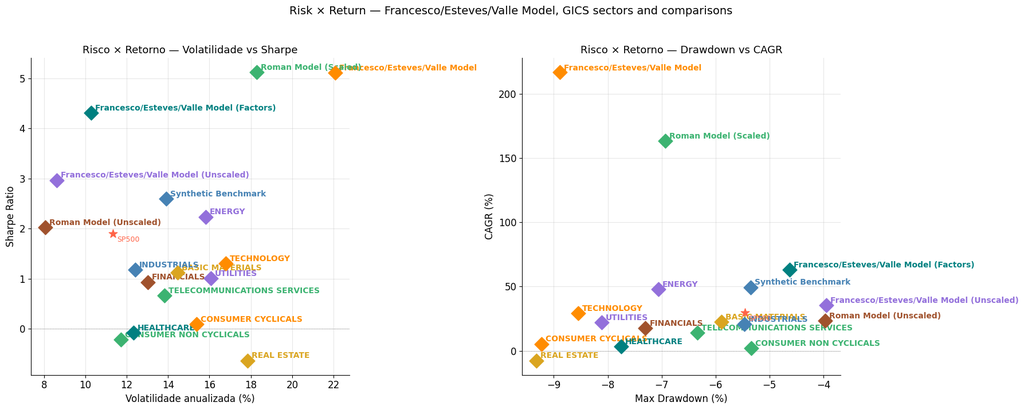

**Risk × Return (scatter)**